# Calibración y Selección de Modelos

Análisis de Datos II

2022-10-17

# Introducción

[figure not shown]

### Paquetes a utilizar

```python
import os
import pandas as pd
import numpy  as np
import matplotlib.pyplot as plt
from sklearn.model_selection import train_test_split
from sklearn.metrics import confusion_matrix
from pandas import DataFrame
from matplotlib import colors as mcolors
import warnings
warnings.filterwarnings('ignore')
```

# Clase Analisis_Predictivo

```python
from pandas import DataFrame
import seaborn as sns

class Analisis_Predictivo:

    def __init__(self,datos:DataFrame, predecir:str, predictoras = [],
                 modelo = None,train_size = 80,random_state = None):
        '''
        datos: Datos completos y listos para construir un modelo

        modelo: Instancia de una Clase de un método de clasificación(KNN,Árboles,SVM,etc).
        Si no especifica un modelo no podrá utilizar el método fit_n_review()

        predecir: Nombre de la variable a predecir

        predictoras: Lista de los nombres de las variables predictoras.
        Si vacío entonces utiliza todas las variables presentes excepto la variable a predecir.

        train_size: Proporción de la tabla de entrenamiento respecto a la original.

        random_state: Semilla aleatoria para la división de datos(training-testing).
        '''
        self.__datos = datos
        self.__predecir = predecir
        self.__predictoras = predictoras
        self.__modelo = modelo
        self.__random_state = random_state
        if modelo != None:
            self.__train_size = train_size
            self._training_testing()

    @property
    def datos(self):
        return self.__datos

    @property
    def predecir(self):
        return self.__predecir

    @property
    def predictoras(self):
        return self.__predictoras

    @property
    def modelo(self):
        return self.__modelo

    @property
    def random_state(self):
        return self.__random_state

    @property
    def train_size(self):
        return self.__train_size

    @datos.setter
    def datos(self, datos):
        self.__datos = datos

    @predecir.setter
    def predecir(self, predecir):
        self.__predecir = predecir

    @predictoras.setter
    def predictoras(self, predictoras):
        self.__predictoras = predictoras

    @modelo.setter
    def modelo(self, modelo):
        self.__modelo = modelo

    @random_state.setter
    def random_state(self, random_state):
        self.__random_state = random_state

    @train_size.setter
    def train_size(self, train_size):
        self.__train_size = train_size

    def _training_testing(self):
        if len(self.predictoras) == 0:
            X = self.datos.drop(columns=[self.predecir])
        else:
            X = self.datos[self.predictoras]

        y = self.datos[self.predecir].values

        train_test = train_test_split(X, y, train_size=self.train_size,
                                      random_state=self.random_state)
        self.X_train, self.X_test,self.y_train, self.y_test = train_test

    def fit_predict(self):
        if(self.modelo != None):
            self.modelo.fit(self.X_train,self.y_train)
            return self.modelo.predict(self.X_test)

    def fit_predict_resultados(self, imprimir = True):
        if(self.modelo != None):
            y = self.datos[self.predecir].values
            prediccion = self.fit_predict()
            MC = confusion_matrix(self.y_test, prediccion)
            indices = self.indices_general(MC,list(np.unique(y)))
            if imprimir == True:
                for k in indices:
                    print("\n%s:\n%s"%(k,str(indices[k])))

            return indices

    def indices_general(self,MC, nombres = None):
        "Método para calcular los índices de calidad de la predicción"
        precision_global = np.sum(MC.diagonal()) / np.sum(MC)
        error_global = 1 - precision_global
        precision_categoria  = pd.DataFrame(MC.diagonal()/np.sum(MC,axis = 1)).T
        if nombres!=None:
            precision_categoria.columns = nombres
        return {"Matriz de Confusión":MC,
                "Precisión Global":precision_global,
                "Error Global":error_global,
                "Precisión por categoría":precision_categoria}

    def distribucion_variable_predecir(self):
        "Método para graficar la distribución de la variable a predecir"
        variable_predict = self.predecir
        data = self.datos
        colors = list(dict(**mcolors.CSS4_COLORS))
        df = pd.crosstab(index=data[variable_predict],columns="valor") / data[variable_predict].count()
        fig = plt.figure(figsize=(10,9))
        g = fig.add_subplot(111)
        countv = 0
        titulo = "Distribución de la variable %s" % variable_predict
        for i in range(df.shape[0]):
            g.barh(1,df.iloc[i],left = countv, align='center',color=colors[11+i],label= df.iloc[i].name)
            countv = countv + df.iloc[i]
        vals = g.get_xticks()
        g.set_xlim(0,1)
        g.set_yticklabels("")
        g.set_title(titulo)
        g.set_ylabel(variable_predict)
        g.set_xticklabels(['{:.0%}'.format(x) for x in vals])
        countv = 0
        for v in df.iloc[:,0]:
            g.text(np.mean([countv,countv+v]) - 0.03, 1 , '{:.1%}'.format(v), color='black', fontweight='bold')
            countv = countv + v
        g.legend(loc='upper center', bbox_to_anchor=(1.08, 1), shadow=True, ncol=1)

    def poder_predictivo_categorica(self, var:str):
        "Método para ver la distribución de una variable categórica respecto a la predecir"
        data = self.datos
        variable_predict = self.predecir
        df = pd.crosstab(index= data[var],columns=data[variable_predict])
        df = df.div(df.sum(axis=1),axis=0)
        titulo = "Distribución de la variable %s según la variable %s" % (var,variable_predict)
        g = df.plot(kind='barh',stacked=True,legend = True, figsize = (10,9), \
                    xlim = (0,1),title = titulo, width = 0.8)
        vals = g.get_xticks()
        g.set_xticklabels(['{:.0%}'.format(x) for x in vals])
        g.legend(loc='upper center', bbox_to_anchor=(1.08, 1), shadow=True, ncol=1)
        for bars in g.containers:
            plt.setp(bars, width=.9)
        for i in range(df.shape[0]):
            countv = 0
            for v in df.iloc[i]:
                g.text(np.mean([countv,countv+v]) - 0.03, i , '{:.1%}'.format(v), color='black', fontweight='bold')
                countv = countv + v


    def poder_predictivo_numerica(self,var:str):
        "Función para ver la distribución de una variable numérica respecto a la predecir"
        sns.FacetGrid(self.datos, hue=self.predecir, height=6).map(sns.kdeplot, var, shade=True).add_legend()
```

# Medición correcta del error

## Ejemplo con los datos de Iris

```python
import numpy as np
import pandas as pd
import os

from sklearn.model_selection import train_test_split
from sklearn.model_selection import KFold

import matplotlib.pyplot as plt

from sklearn.neighbors import KNeighborsClassifier
```

```python
datos = pd.read_csv('datos/iris.csv', delimiter = ';', decimal = ".")
print(datos.shape)
```

```
## (150, 5)
```

```python
print(datos.head())
```

```
##    s.largo  s.ancho  p.largo  p.ancho    tipo
## 0      5.1      3.5      1.4      0.2  setosa
## 1      4.9      3.0      1.4      0.2  setosa
## 2      4.7      3.2      1.3      0.2  setosa
## 3      4.6      3.1      1.5      0.2  setosa
## 4      5.0      3.6      1.4      0.2  setosa
```

```python
print(datos.info())
```

```
## <class 'pandas.core.frame.DataFrame'>
## RangeIndex: 150 entries, 0 to 149
## Data columns (total 5 columns):
##  #   Column   Non-Null Count  Dtype
## ---  ------   --------------  -----
##  0   s.largo  150 non-null    float64
##  1   s.ancho  150 non-null    float64
##  2   p.largo  150 non-null    float64
##  3   p.ancho  150 non-null    float64
##  4   tipo     150 non-null    object
## dtypes: float64(4), object(1)
## memory usage: 6.0+ KB
## None
```

### Elimina la variable catégorica, deja las variables predictoras en X.

```python
X = datos.iloc[:, :4]
print(X.head())
```

```
##    s.largo  s.ancho  p.largo  p.ancho
## 0      5.1      3.5      1.4      0.2
## 1      4.9      3.0      1.4      0.2
## 2      4.7      3.2      1.3      0.2
## 3      4.6      3.1      1.5      0.2
## 4      5.0      3.6      1.4      0.2
```

### Deja la variable a predecir en y.

```python
y = datos.iloc[:, 4:5]
print(y.head())
```

```
##      tipo
## 0  setosa
## 1  setosa
## 2  setosa
## 3  setosa
## 4  setosa
```

## Tabla de aprendizaje-prueba

### Tiene dos grandes problemas:

### La estimación del error tiende a ser muy variable dependiendo de cuáles datos quedan en la tabla de aprendizaje y cuáles en la tabla de testing. Se tiende a sobrestimar el error, es decir, es mucho mayor el error en la tabla de testing que en toda la tabla de datos.

### Enfoque Training-Testing para medir el error.

```python
mc_tt = []

for i in range(10):
    X_train, X_test, y_train, y_test = train_test_split(X, y, train_size = 0.7)

    knn = KNeighborsClassifier(n_neighbors = 8)
    noimprimir = knn.fit(X_train, y_train.values.ravel())
    MC = confusion_matrix(y_test, knn.predict(X_test))

    mc_tt.append(MC)

mc_tt
```

```
## [array([[11,  0,  0],
##        [ 0, 17,  1],
##        [ 0,  1, 15]]), array([[13,  0,  0],
##        [ 0, 14,  0],
##        [ 0,  0, 18]]), array([[16,  0,  0],
##        [ 0, 19,  2],
##        [ 0,  0,  8]]), array([[13,  0,  0],
##        [ 0, 15,  0],
##        [ 0,  1, 16]]), array([[11,  0,  0],
##        [ 0, 12,  3],
##        [ 0,  1, 18]]), array([[18,  0,  0],
##        [ 0, 15,  0],
##        [ 0,  0, 12]]), array([[11,  0,  0],
##        [ 0, 20,  0],
##        [ 0,  2, 12]]), array([[15,  0,  0],
##        [ 0, 21,  0],
##        [ 0,  0,  9]]), array([[13,  0,  0],
##        [ 0, 11,  1],
##        [ 0,  2, 18]]), array([[16,  0,  0],
##        [ 0, 12,  0],
##        [ 0,  4, 13]])]
```

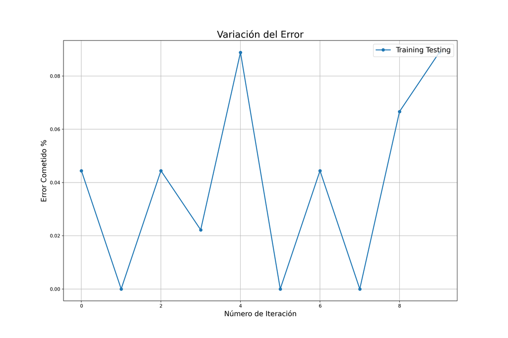

```python
# Obtención del error global
error_tt = []
for mc in mc_tt:
  error_tt.append(1 - (sum(mc.diagonal())/mc.sum()))

plt.figure(figsize = (15, 10))
plt.plot(error_tt, 'o-', lw = 2)
plt.xlabel("Número de Iteración", fontsize = 15)
plt.ylabel("Error Cometido %",    fontsize = 15)
plt.title("Variación del Error",  fontsize = 20)
plt.grid(True)
plt.legend(['Training Testing'], loc = 'upper right', fontsize = 15)
```

## Tabla Completa

### Enfoque Tabla Completa (como tabla de training y testing) para medir el error

```python
mc_tc = []

for i in range(10):
    knn = KNeighborsClassifier(n_neighbors = 8)
    noimprimir = knn.fit(X, y.values.ravel())
    MC = confusion_matrix(y_test, knn.predict(X_test))

    mc_tc.append(MC)

mc_tc
```

```
## [array([[16,  0,  0],
##        [ 0, 12,  0],
##        [ 0,  1, 16]]), array([[16,  0,  0],
##        [ 0, 12,  0],
##        [ 0,  1, 16]]), array([[16,  0,  0],
##        [ 0, 12,  0],
##        [ 0,  1, 16]]), array([[16,  0,  0],
##        [ 0, 12,  0],
##        [ 0,  1, 16]]), array([[16,  0,  0],
##        [ 0, 12,  0],
##        [ 0,  1, 16]]), array([[16,  0,  0],
##        [ 0, 12,  0],
##        [ 0,  1, 16]]), array([[16,  0,  0],
##        [ 0, 12,  0],
##        [ 0,  1, 16]]), array([[16,  0,  0],
##        [ 0, 12,  0],
##        [ 0,  1, 16]]), array([[16,  0,  0],
##        [ 0, 12,  0],
##        [ 0,  1, 16]]), array([[16,  0,  0],
##        [ 0, 12,  0],
##        [ 0,  1, 16]])]
```

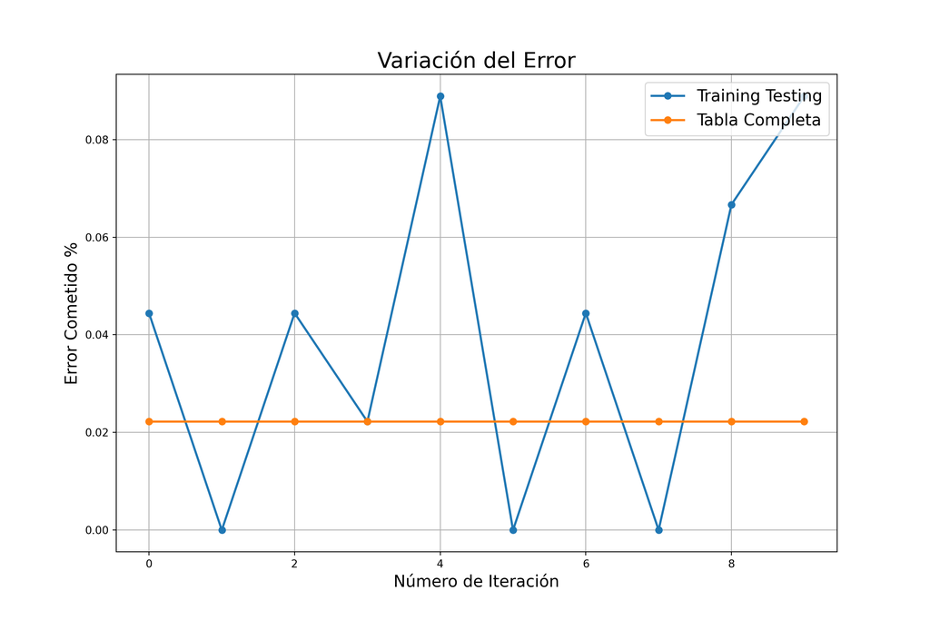

```python
# Obtención del error global
error_tc = []
for mc in mc_tc:
  error_tc.append(1 - (sum(mc.diagonal())/mc.sum()))

plt.figure(figsize=(12,8))
plt.plot(error_tt, 'o-', lw = 2)
plt.plot(error_tc, 'o-', lw = 2)
plt.xlabel("Número de Iteración", fontsize = 15)
plt.ylabel("Error Cometido %", fontsize = 15)
plt.title("Variación del Error", fontsize = 20)
plt.grid(True)
plt.legend(['Training Testing', 'Tabla Completa'], loc = 'upper right', fontsize = 15)
```

## Validación Cruzada Dejando Uno Fuera

### Enfoque Validación Cruzada Dejando Uno Fuera (Leave-One-Out Cross-Validation, LOOCV) para medir el error.

### Tiene dos ventajas:

### El error está menos sobrestimado. Hay menor variación en el error

### Desventaja:

### Puede tardar demasiado tiempo pues tiene que construir n modelos donde n es la cantidad de filas de la matriz.

```python
n = datos.shape[0]
mc_loo = []

for i in range(10):
  prediccion = []

  for j in range(n):
    X_train = X.drop(j, axis = 0)
    X_test = X.iloc[j, :]
    y_train = y.drop(j, axis = 0)
    y_test = y.iloc[j]

    knn = KNeighborsClassifier(n_neighbors = 8)
    noimprimir = knn.fit(X_train, y_train.values.ravel())
    pred_i = knn.predict(pd.DataFrame(X_test).T)

    prediccion.append(pred_i)

  MC = confusion_matrix(y, prediccion)
  mc_loo.append(MC)

mc_loo
```

```
## [array([[50,  0,  0],
##        [ 0, 48,  2],
##        [ 0,  3, 47]]), array([[50,  0,  0],
##        [ 0, 48,  2],
##        [ 0,  3, 47]]), array([[50,  0,  0],
##        [ 0, 48,  2],
##        [ 0,  3, 47]]), array([[50,  0,  0],
##        [ 0, 48,  2],
##        [ 0,  3, 47]]), array([[50,  0,  0],
##        [ 0, 48,  2],
##        [ 0,  3, 47]]), array([[50,  0,  0],
##        [ 0, 48,  2],
##        [ 0,  3, 47]]), array([[50,  0,  0],
##        [ 0, 48,  2],
##        [ 0,  3, 47]]), array([[50,  0,  0],
##        [ 0, 48,  2],
##        [ 0,  3, 47]]), array([[50,  0,  0],
##        [ 0, 48,  2],
##        [ 0,  3, 47]]), array([[50,  0,  0],
##        [ 0, 48,  2],
##        [ 0,  3, 47]])]
```

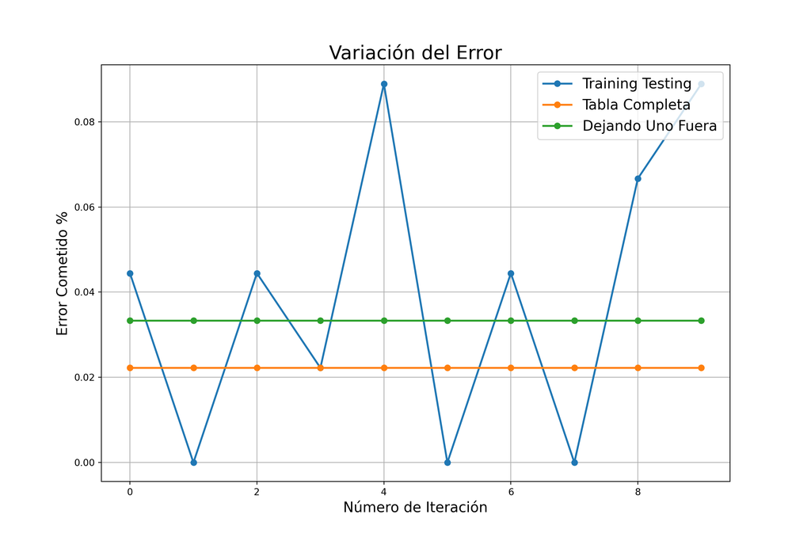

```python
# Obtención del error global
error_loo = []
for mc in mc_loo:
  error_loo.append(1 - (sum(mc.diagonal())/mc.sum()))

plt.figure(figsize=(12,8))
plt.plot(error_tt, 'o-', lw = 2)
plt.plot(error_tc, 'o-', lw = 2)
plt.plot(error_loo, 'o-', lw = 2)
plt.xlabel("Número de Iteración", fontsize = 15)
plt.ylabel("Error Cometido %", fontsize = 15)
plt.title("Variación del Error", fontsize = 20)
plt.grid(True)
plt.legend(['Training Testing', 'Tabla Completa', 'Dejando Uno Fuera'], loc = 'upper right', fontsize = 15)
```

## Validación Cruzada usando K grupos

### Validación Cruzada usando K grupos (K-Fold Cross-Validation, CV).

### Para mayor información de la Clase KFold, presionar [aquí.](https://scikit-learn.org/stable/modules/generated/sklearn.model_selection.KFold.html)

### Ejemplos de la salida del método split().

```python
kfold = KFold(n_splits = 2, shuffle = True)
folds = kfold.split(X, y)
for train_index, test_index in folds:
    print("TRAIN:", train_index, "\n", "TEST:", test_index)
```

```
## TRAIN: [  1   3   5   7   9  10  12  13  14  15  17  19  21  23  25  28  31  32
##   33  34  36  38  39  40  41  47  48  49  51  53  55  56  60  68  71  72
##   74  76  78  79  80  81  83  84  85  87  88  89  92  93  96  97 104 108
##  109 112 114 118 120 121 122 126 127 128 129 131 132 133 135 142 143 144
##  146 148 149]
##  TEST: [  0   2   4   6   8  11  16  18  20  22  24  26  27  29  30  35  37  42
##   43  44  45  46  50  52  54  57  58  59  61  62  63  64  65  66  67  69
##   70  73  75  77  82  86  90  91  94  95  98  99 100 101 102 103 105 106
##  107 110 111 113 115 116 117 119 123 124 125 130 134 136 137 138 139 140
##  141 145 147]
## TRAIN: [  0   2   4   6   8  11  16  18  20  22  24  26  27  29  30  35  37  42
##   43  44  45  46  50  52  54  57  58  59  61  62  63  64  65  66  67  69
##   70  73  75  77  82  86  90  91  94  95  98  99 100 101 102 103 105 106
##  107 110 111 113 115 116 117 119 123 124 125 130 134 136 137 138 139 140
##  141 145 147]
##  TEST: [  1   3   5   7   9  10  12  13  14  15  17  19  21  23  25  28  31  32
##   33  34  36  38  39  40  41  47  48  49  51  53  55  56  60  68  71  72
##   74  76  78  79  80  81  83  84  85  87  88  89  92  93  96  97 104 108
##  109 112 114 118 120 121 122 126 127 128 129 131 132 133 135 142 143 144
##  146 148 149]
```

```python
kfold = KFold(n_splits = 3, shuffle = True)
folds = kfold.split(X, y)
for train_index, test_index in folds:
    print("TRAIN:", train_index, "\n", "TEST:", test_index)
```

```
## TRAIN: [  0   1   2   3   4   5   8  11  12  13  14  15  16  17  19  20  21  24
##   25  26  27  28  29  30  33  35  37  40  41  42  43  44  45  49  51  52
##   53  55  57  59  60  61  62  63  64  65  67  68  69  70  74  76  78  79
##   80  81  82  84  87  88  89  91  92  93  95  97  99 100 102 103 105 106
##  107 108 109 112 113 114 115 117 119 121 122 123 126 127 128 129 130 131
##  133 136 138 140 141 143 144 145 146 148]
##  TEST: [  6   7   9  10  18  22  23  31  32  34  36  38  39  46  47  48  50  54
##   56  58  66  71  72  73  75  77  83  85  86  90  94  96  98 101 104 110
##  111 116 118 120 124 125 132 134 135 137 139 142 147 149]
## TRAIN: [  2   5   6   7   9  10  12  13  16  17  18  22  23  25  27  28  29  31
##   32  34  36  37  38  39  40  46  47  48  50  51  52  54  56  58  61  63
##   64  66  67  68  71  72  73  75  76  77  78  79  80  81  82  83  84  85
##   86  88  89  90  91  94  95  96  98 101 102 104 105 106 107 110 111 112
##  113 114 116 117 118 120 122 123 124 125 127 128 129 130 132 133 134 135
##  137 138 139 140 142 143 144 147 148 149]
##  TEST: [  0   1   3   4   8  11  14  15  19  20  21  24  26  30  33  35  41  42
##   43  44  45  49  53  55  57  59  60  62  65  69  70  74  87  92  93  97
##   99 100 103 108 109 115 119 121 126 131 136 141 145 146]
## TRAIN: [  0   1   3   4   6   7   8   9  10  11  14  15  18  19  20  21  22  23
##   24  26  30  31  32  33  34  35  36  38  39  41  42  43  44  45  46  47
##   48  49  50  53  54  55  56  57  58  59  60  62  65  66  69  70  71  72
##   73  74  75  77  83  85  86  87  90  92  93  94  96  97  98  99 100 101
##  103 104 108 109 110 111 115 116 118 119 120 121 124 125 126 131 132 134
##  135 136 137 139 141 142 145 146 147 149]
##  TEST: [  2   5  12  13  16  17  25  27  28  29  37  40  51  52  61  63  64  67
##   68  76  78  79  80  81  82  84  88  89  91  95 102 105 106 107 112 113
##  114 117 122 123 127 128 129 130 133 138 140 143 144 148]
```

### Enfoque Validación Cruzada usando K = 10 grupos.

```python
mc_cv = []

for i in range(10):
  kfold = KFold(n_splits = 10, shuffle = True)
  MC = 0

  for train, test in kfold.split(X, y):
    knn = KNeighborsClassifier(n_neighbors = 8)
    noimprimir = knn.fit(X.iloc[train], y.iloc[train].values.ravel())
    pred_fold = knn.predict(X.iloc[test])
    MC = MC + confusion_matrix(y.iloc[test], pred_fold)

  mc_cv.append(MC)

mc_cv
```

```
## [array([[50,  0,  0],
##        [ 0, 48,  2],
##        [ 0,  2, 48]]), array([[50,  0,  0],
##        [ 0, 48,  2],
##        [ 0,  4, 46]]), array([[50,  0,  0],
##        [ 0, 48,  2],
##        [ 0,  3, 47]]), array([[50,  0,  0],
##        [ 0, 47,  3],
##        [ 0,  4, 46]]), array([[50,  0,  0],
##        [ 0, 49,  1],
##        [ 0,  2, 48]]), array([[50,  0,  0],
##        [ 0, 48,  2],
##        [ 0,  3, 47]]), array([[50,  0,  0],
##        [ 0, 49,  1],
##        [ 0,  2, 48]]), array([[50,  0,  0],
##        [ 0, 47,  3],
##        [ 0,  4, 46]]), array([[50,  0,  0],
##        [ 0, 47,  3],
##        [ 0,  3, 47]]), array([[50,  0,  0],
##        [ 0, 48,  2],
##        [ 0,  3, 47]])]
```

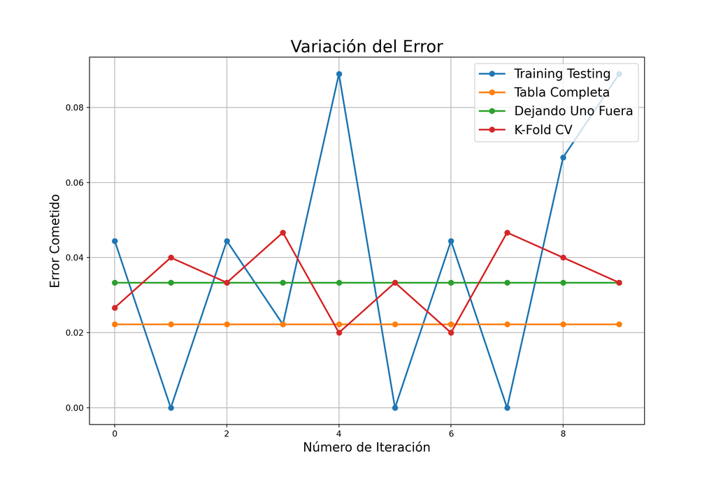

```python
# Obtención del error global
error_cv = []
for mc in mc_cv:
  error_cv.append(1 - (sum(mc.diagonal())/mc.sum()))

plt.figure(figsize=(12, 8))
plt.plot(error_tt, 'o-', lw = 2)
plt.plot(error_tc, 'o-', lw = 2)
plt.plot(error_loo, 'o-', lw = 2)
plt.plot(error_cv, 'o-', lw = 2)
plt.xlabel("Número de Iteración", fontsize = 15)
plt.ylabel("Error Cometido", fontsize = 15)
plt.title("Variación del Error", fontsize = 20)
plt.grid(True)
plt.legend(['Training Testing', 'Tabla Completa', 'Dejando Uno Fuera', 'K-Fold CV'], loc = 'upper right', fontsize = 15)
```

# Calibración y Selección de Modelos Predictivos

## Ejemplo 1

## Ejemplo con los datos de Scoring de Crédito

### Calibración del modelo `SVC`.

```python
import os
import pandas as pd
from sklearn.svm import SVC
```

```python
# Se leen los datos
datos = pd.read_csv('datos/MuestraCredito5000V2.csv',delimiter=';',decimal=".")

# Convierte las variables de object a categórica
datos['IngresoNeto'] = datos['IngresoNeto'].astype('category')
datos['CoefCreditoAvaluo'] = datos['CoefCreditoAvaluo'].astype('category')
datos['MontoCuota'] = datos['MontoCuota'].astype('category')
datos['GradoAcademico'] = datos['GradoAcademico'].astype('category')
# Recodifica las categorías usando números
datos["MontoCuota"] = datos["MontoCuota"].cat.codes
datos["GradoAcademico"] = datos["GradoAcademico"].cat.codes
# Convierte las variables de entero a categórica
datos['MontoCuota'] = datos['MontoCuota'].astype('category')
datos['GradoAcademico'] = datos['GradoAcademico'].astype('category')

# Prepara los datos
X = datos.iloc[:,:5]
y = datos.iloc[:,5:6]
```

## Usaremos Validación Cruzada con 10 grupos (10 folds)

```python
mcs_sigmoid = []
mcs_rbf     = []
mcs_poly    = []

for i in range(5):
  kfold = KFold(n_splits = 10, shuffle = True)
  mc_sigmoid = 0
  mc_rbf     = 0
  mc_poly    = 0

  for train, test in kfold.split(X, y):
    # sigmoid
    modelo = SVC(kernel = 'sigmoid', gamma = 'scale')
    noimprimir = modelo.fit(X.iloc[train], y.iloc[train].values.ravel())
    pred_fold  = modelo.predict(X.iloc[test])
    mc_sigmoid = mc_sigmoid + confusion_matrix(y.iloc[test], pred_fold)

    # rbf
    modelo = SVC(kernel = 'rbf', gamma = 'scale')
    noimprimir = modelo.fit(X.iloc[train], y.iloc[train].values.ravel())
    pred_fold  = modelo.predict(X.iloc[test])
    mc_rbf     = mc_rbf + confusion_matrix(y.iloc[test], pred_fold)

    # poly
    modelo = SVC(kernel = 'poly', gamma = 'scale')
    noimprimir = modelo.fit(X.iloc[train], y.iloc[train].values.ravel())
    pred_fold  = modelo.predict(X.iloc[test])
    mc_poly    = mc_poly + confusion_matrix(y.iloc[test], pred_fold)

  mcs_sigmoid.append(mc_sigmoid)
  mcs_rbf.append(mc_rbf)
  mcs_poly.append(mc_poly)

mcs_sigmoid
```

```
## [array([[ 161,  544],
##        [ 512, 3783]]), array([[ 160,  545],
##        [ 516, 3779]]), array([[ 157,  548],
##        [ 509, 3786]]), array([[ 159,  546],
##        [ 512, 3783]]), array([[ 158,  547],
##        [ 514, 3781]])]
```

```python
mcs_rbf
```

```
## [array([[   0,  705],
##        [   0, 4295]]), array([[   0,  705],
##        [   0, 4295]]), array([[   0,  705],
##        [   0, 4295]]), array([[   0,  705],
##        [   0, 4295]]), array([[   0,  705],
##        [   0, 4295]])]
```

```python
mcs_poly
```

```
## [array([[   0,  705],
##        [   0, 4295]]), array([[   0,  705],
##        [   0, 4295]]), array([[   0,  705],
##        [   0, 4295]]), array([[   0,  705],
##        [   0, 4295]]), array([[   0,  705],
##        [   0, 4295]])]
```

## Gráfico Comparativo

```python
import numpy as np
import seaborn as sns
import matplotlib.pyplot as plt

labels = ['sigmoid', 'rbf', 'poly']

mc_sigmoid = np.round(np.sum(mc for mc in mcs_sigmoid) / 5)
mc_rbf     = np.round(np.sum(mc for mc in mcs_rbf) / 5)
mc_poly    = np.round(np.sum(mc for mc in mcs_poly) / 5)
mcs = [mc_sigmoid, mc_rbf, mc_poly]

res = pd.DataFrame()
for i in range(3):
  PG = np.round(np.diag(mcs[i]).sum() / mcs[i].sum() * 100, 2)
  PC = np.round(mcs[i].diagonal()/np.sum(mcs[i],axis = 1) * 100, 2)
  PP = PC[1]
  PN = PC[0]

  res = pd.concat([res, pd.DataFrame([[labels[i], "Global", PG]], columns = ["Kernel", "Precision", "Valor"])])
  res = pd.concat([res, pd.DataFrame([[labels[i], "Si", PP]], columns = ["Kernel", "Precision", "Valor"])])
  res = pd.concat([res, pd.DataFrame([[labels[i], "No", PN]], columns = ["Kernel", "Precision", "Valor"])])
```

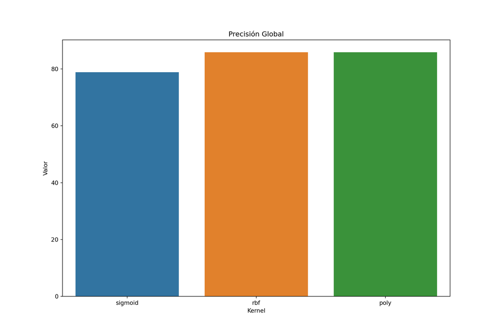

```python
p_global = res.loc[res.Precision == "Global", ]
fig, ax = plt.subplots(figsize = (12, 8))
sns.barplot(x = 'Kernel', y = 'Valor', data = p_global)
plt.title("Precisión Global")
plt.show()
```

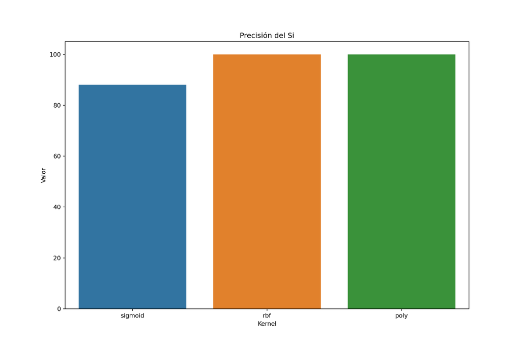

```python
p_si = res.loc[res.Precision == "Si", ]
fig, ax = plt.subplots(figsize = (12, 8))
sns.barplot(x = 'Kernel', y = 'Valor', data = p_si)
plt.title("Precisión del Si")
plt.show()
```

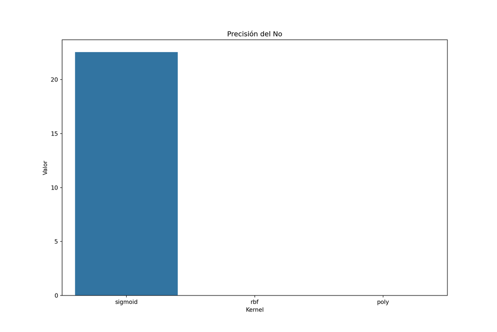

```python
p_no = res.loc[res.Precision == "No", ]
fig, ax = plt.subplots(figsize = (12, 8))
sns.barplot(x = 'Kernel', y = 'Valor', data = p_no)
plt.title("Precisión del No")
plt.show()
```

## Por lo tanto el mejor núcleo es sigmoid.

## Ejemplo 2

### Ejemplo con los datos de Scoring de Crédito.

### Calibración de los modelos predictivos.

### **Se deberían calibrar todos antes, es decir, tal y como hicimos con Máquinas de Soporte Vectorial, deberíamos encontrar la mejor combinación de parámetros en cada método antes de ponerlos a competir. Así se debe hacer en problemas de la vida real, por ahora los vamos a poner a competir a todos con su parametrización que usa por defecto.**

```python
# Se leen los datos
datos = pd.read_csv('datos/MuestraCredito5000V2.csv',delimiter=';',decimal=".")

# Convierte las variables de object a categórica
datos['IngresoNeto'] = datos['IngresoNeto'].astype('category')
datos['CoefCreditoAvaluo'] = datos['CoefCreditoAvaluo'].astype('category')
datos['MontoCuota'] = datos['MontoCuota'].astype('category')
datos['GradoAcademico'] = datos['GradoAcademico'].astype('category')
# Recodifica las categorías usando números
datos["MontoCuota"] = datos["MontoCuota"].cat.codes
datos["GradoAcademico"] = datos["GradoAcademico"].cat.codes
# Convierte las variables de entero a categórica
datos['MontoCuota'] = datos['MontoCuota'].astype('category')
datos['GradoAcademico'] = datos['GradoAcademico'].astype('category')

# Prepara los datos
X = datos.iloc[:,:5]
y = datos.iloc[:,5:6]
```

```python
from sklearn.neighbors import KNeighborsClassifier
from sklearn.tree import DecisionTreeClassifier
from sklearn.ensemble import RandomForestClassifier
from sklearn.ensemble import AdaBoostClassifier
from sklearn.ensemble import GradientBoostingClassifier
from sklearn.svm import SVC
from sklearn.naive_bayes import GaussianNB
from sklearn.discriminant_analysis import LinearDiscriminantAnalysis
from sklearn.discriminant_analysis import QuadraticDiscriminantAnalysis

mcs_knn = []
mcs_arbol = []
mcs_bosques = []
mcs_potenciacion  = []
mcs_xg_potenciacion = []
mcs_svm = []
mcs_bayes = []
mcs_dis_lineal  = []
mcs_dis_cuadratico = []

for i in range(5):
  kfold = KFold(n_splits = 10, shuffle = True)
  mc_knn = 0
  mc_arbol = 0
  mc_bosques = 0
  mc_potenciacion = 0
  mc_xg_potenciacion = 0
  mc_svm = 0
  mc_bayes = 0
  mc_dis_lineal = 0
  mc_dis_cuadratico = 0

  for train, test in kfold.split(X, y):
    # KNN
    modelo     = KNeighborsClassifier(n_neighbors = 71)
    noimprimir = modelo.fit(X.iloc[train], y.iloc[train].values.ravel())
    pred_fold  = modelo.predict(X.iloc[test])
    mc_knn     = mc_knn + confusion_matrix(y.iloc[test], pred_fold)

    # Arbol
    modelo     = DecisionTreeClassifier()
    noimprimir = modelo.fit(X.iloc[train], y.iloc[train].values.ravel())
    pred_fold  = modelo.predict(X.iloc[test])
    mc_arbol   = mc_arbol + confusion_matrix(y.iloc[test], pred_fold)

    # Bosques Aleatorios
    modelo     = RandomForestClassifier(n_estimators = 10)
    noimprimir = modelo.fit(X.iloc[train], y.iloc[train].values.ravel())
    pred_fold  = modelo.predict(X.iloc[test])
    mc_bosques = mc_bosques + confusion_matrix(y.iloc[test], pred_fold)

    # Potenciación (Boosting)
    modelo     = AdaBoostClassifier(n_estimators = 10)
    noimprimir = modelo.fit(X.iloc[train], y.iloc[train].values.ravel())
    pred_fold  = modelo.predict(X.iloc[test])
    mc_potenciacion  = mc_potenciacion + confusion_matrix(y.iloc[test], pred_fold)

    # Potenciación Extrema (XGBoosting)
    modelo     = GradientBoostingClassifier(n_estimators=10)
    noimprimir = modelo.fit(X.iloc[train], y.iloc[train].values.ravel())
    pred_fold  = modelo.predict(X.iloc[test])
    mc_xg_potenciacion = mc_xg_potenciacion + confusion_matrix(y.iloc[test], pred_fold)

    # Máquinas de Soporte Vectorial
    modelo     = SVC(kernel='sigmoid', gamma = 'scale')
    noimprimir = modelo.fit(X.iloc[train], y.iloc[train].values.ravel())
    pred_fold  = modelo.predict(X.iloc[test])
    mc_svm     = mc_svm + confusion_matrix(y.iloc[test], pred_fold)

    # Método Ingenuo de Bayes
    modelo     = GaussianNB()
    noimprimir = modelo.fit(X.iloc[train], y.iloc[train].values.ravel())
    pred_fold  = modelo.predict(X.iloc[test])
    mc_bayes   = mc_bayes + confusion_matrix(y.iloc[test], pred_fold)

    # Análisis Discriminte Lineal
    modelo     = LinearDiscriminantAnalysis(solver = 'lsqr', shrinkage = 'auto')
    noimprimir = modelo.fit(X.iloc[train], y.iloc[train].values.ravel())
    pred_fold  = modelo.predict(X.iloc[test])
    mc_dis_lineal  = mc_dis_lineal + confusion_matrix(y.iloc[test], pred_fold)

    # Análisis Discriminte Cuadrático
    modelo     = QuadraticDiscriminantAnalysis()
    noimprimir = modelo.fit(X.iloc[train], y.iloc[train].values.ravel())
    pred_fold  = modelo.predict(X.iloc[test])
    mc_dis_cuadratico = mc_dis_cuadratico + confusion_matrix(y.iloc[test], pred_fold)

  mcs_knn.append(mc_knn)
  mcs_arbol.append(mc_arbol)
  mcs_bosques.append(mc_bosques)
  mcs_potenciacion.append(mc_potenciacion)
  mcs_xg_potenciacion.append(mc_xg_potenciacion)
  mcs_svm.append(mc_svm)
  mcs_bayes.append(mc_bayes)
  mcs_dis_lineal.append(mc_dis_lineal)
  mcs_dis_cuadratico.append(mc_dis_cuadratico)

mcs_knn
```

```
## [array([[   0,  705],
##        [   0, 4295]]), array([[   0,  705],
##        [   0, 4295]]), array([[   0,  705],
##        [   0, 4295]]), array([[   0,  705],
##        [   0, 4295]]), array([[   0,  705],
##        [   0, 4295]])]
```

```python
mcs_arbol
```

```
## [array([[ 521,  184],
##        [ 181, 4114]]), array([[ 520,  185],
##        [ 187, 4108]]), array([[ 521,  184],
##        [ 181, 4114]]), array([[ 516,  189],
##        [ 183, 4112]]), array([[ 523,  182],
##        [ 185, 4110]])]
```

```python
mcs_bosques
```

```
## [array([[ 532,  173],
##        [ 156, 4139]]), array([[ 528,  177],
##        [ 167, 4128]]), array([[ 524,  181],
##        [ 161, 4134]]), array([[ 530,  175],
##        [ 168, 4127]]), array([[ 533,  172],
##        [ 165, 4130]])]
```

```python
mcs_potenciacion
```

```
## [array([[ 179,  526],
##        [  48, 4247]]), array([[ 184,  521],
##        [  52, 4243]]), array([[ 193,  512],
##        [  54, 4241]]), array([[ 182,  523],
##        [  50, 4245]]), array([[ 187,  518],
##        [  52, 4243]])]
```

```python
mcs_xg_potenciacion
```

```
## [array([[ 368,  337],
##        [  23, 4272]]), array([[ 348,  357],
##        [  22, 4273]]), array([[ 367,  338],
##        [  24, 4271]]), array([[ 372,  333],
##        [  25, 4270]]), array([[ 367,  338],
##        [  23, 4272]])]
```

```python
mcs_svm
```

```
## [array([[ 161,  544],
##        [ 512, 3783]]), array([[ 160,  545],
##        [ 508, 3787]]), array([[ 156,  549],
##        [ 508, 3787]]), array([[ 159,  546],
##        [ 520, 3775]]), array([[ 160,  545],
##        [ 511, 3784]])]
```

```python
mcs_bayes
```

```
## [array([[  71,  634],
##        [ 174, 4121]]), array([[  71,  634],
##        [ 171, 4124]]), array([[  70,  635],
##        [ 173, 4122]]), array([[  70,  635],
##        [ 170, 4125]]), array([[  68,  637],
##        [ 173, 4122]])]
```

```python
mcs_dis_lineal
```

```
## [array([[  42,  663],
##        [  94, 4201]]), array([[  44,  661],
##        [  93, 4202]]), array([[  44,  661],
##        [  99, 4196]]), array([[  43,  662],
##        [  97, 4198]]), array([[  44,  661],
##        [  92, 4203]])]
```

```python
mcs_dis_cuadratico
```

```
## [array([[ 141,  564],
##        [ 221, 4074]]), array([[ 137,  568],
##        [ 222, 4073]]), array([[ 139,  566],
##        [ 222, 4073]]), array([[ 144,  561],
##        [ 221, 4074]]), array([[ 141,  564],
##        [ 224, 4071]])]
```

### Gráfico Comparativo

```python
import numpy as np
import seaborn as sns
import matplotlib.pyplot as plt

labels = ['KNN', 'Arbol', 'Bosques', 'Potenciacion', 'XGB', 'SVM', 'Bayes', 'Lineal', 'Cuadratico']

mc_knn =             np.round(np.sum(mc for mc in mcs_knn) / 5)
mc_arbol =           np.round(np.sum(mc for mc in mcs_arbol) / 5)
mc_bosques =         np.round(np.sum(mc for mc in mcs_bosques) / 5)
mc_potenciacion =    np.round(np.sum(mc for mc in mcs_potenciacion) / 5)
mc_xg_potenciacion = np.round(np.sum(mc for mc in mcs_xg_potenciacion) / 5)
mc_svm =             np.round(np.sum(mc for mc in mcs_svm) / 5)
mc_bayes =           np.round(np.sum(mc for mc in mcs_bayes) / 5)
mc_dis_lineal =      np.round(np.sum(mc for mc in mcs_dis_lineal) / 5)
mc_dis_cuadratico =  np.round(np.sum(mc for mc in mcs_dis_cuadratico) / 5)
mcs = [mc_knn, mc_arbol, mc_bosques, mc_potenciacion, mc_xg_potenciacion,
       mc_svm, mc_bayes, mc_dis_lineal, mc_dis_cuadratico]

res = pd.DataFrame()
for i in range(9):
  PG = np.round(np.diag(mcs[i]).sum() / mcs[i].sum() * 100, 2)
  PC = np.round(mcs[i].diagonal()/np.sum(mcs[i],axis = 1) * 100, 2)
  PP = PC[1]
  PN = PC[0]

  res = pd.concat([res, pd.DataFrame([[labels[i], "Global", PG]], columns = ["Modelo", "Precision", "Valor"])])
  res = pd.concat([res, pd.DataFrame([[labels[i], "Si", PP]], columns = ["Modelo", "Precision", "Valor"])])
  res = pd.concat([res, pd.DataFrame([[labels[i], "No", PN]], columns = ["Modelo", "Precision", "Valor"])])
```

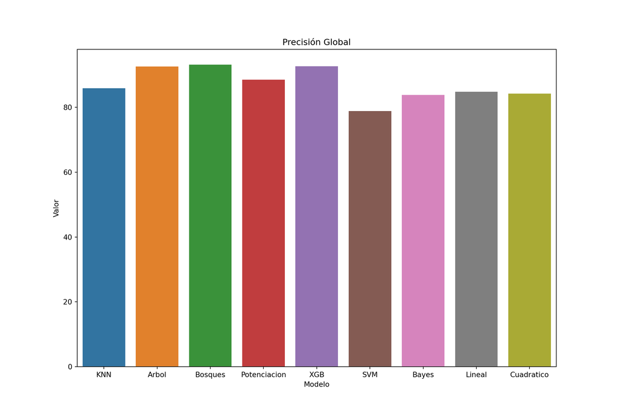

```python
p_global = res.loc[res.Precision == "Global", ]
fig, ax = plt.subplots(figsize = (12, 8))
sns.barplot(x = 'Modelo', y = 'Valor', data = p_global)
plt.title("Precisión Global")
plt.show()
```

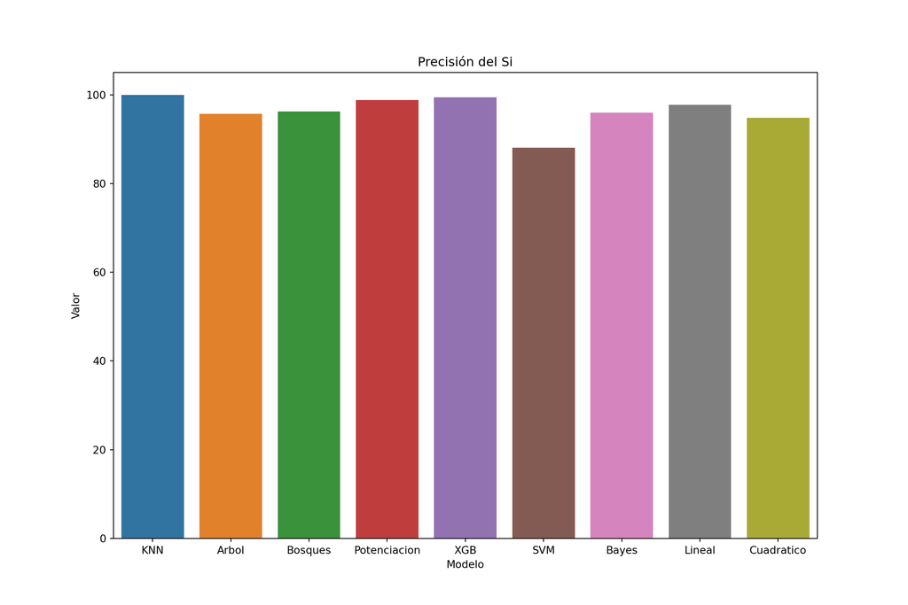

```python
p_si = res.loc[res.Precision == "Si", ]
fig, ax = plt.subplots(figsize = (12, 8))
sns.barplot(x = 'Modelo', y = 'Valor', data = p_si)
plt.title("Precisión del Si")
plt.show()
```

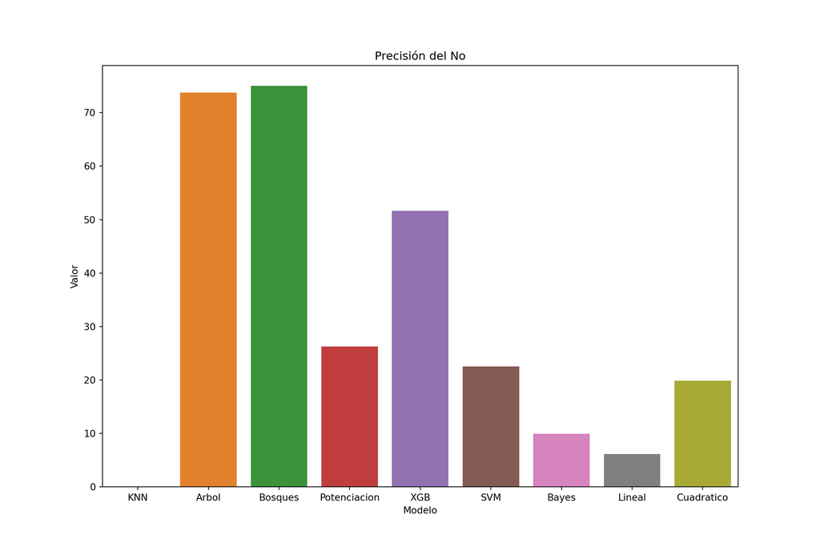

```python
p_no = res.loc[res.Precision == "No", ]
fig, ax = plt.subplots(figsize = (12, 8))
sns.barplot(x = 'Modelo', y = 'Valor', data = p_no)
plt.title("Precisión del No")
plt.show()
```

# Calibración y Selección de Modelos Predictivos con Sklearn

## Ejemplo 1

## Ejemplo con los datos de Scoring de Crédito

### Calibración del modelo `SVC`.

```python
import os
import pandas as pd
from sklearn.svm import SVC
from sklearn.model_selection import cross_val_predict
from sklearn.model_selection import KFold
from sklearn.model_selection import LeaveOneOut
```

```python
# Se leen los datos
datos = pd.read_csv('datos/MuestraCredito5000V2.csv',delimiter=';',decimal=".")

# Convierte las variables de object a categórica
datos['IngresoNeto'] = datos['IngresoNeto'].astype('category')
datos['CoefCreditoAvaluo'] = datos['CoefCreditoAvaluo'].astype('category')
datos['MontoCuota'] = datos['MontoCuota'].astype('category')
datos['GradoAcademico'] = datos['GradoAcademico'].astype('category')
# Recodifica las categorías usando números
datos["MontoCuota"] = datos["MontoCuota"].cat.codes
datos["GradoAcademico"] = datos["GradoAcademico"].cat.codes
# Convierte las variables de entero a categórica
datos['MontoCuota'] = datos['MontoCuota'].astype('category')
datos['GradoAcademico'] = datos['GradoAcademico'].astype('category')

# Prepara los datos
X = datos.iloc[:,:5]
y = datos.iloc[:,5:6]
```

## Usaremos Validación Cruzada con 10 grupos (10 folds)

### Primero con el núcleo `sigmoid`

```python
instancia_kfold = KFold(n_splits=10)
prediccion = cross_val_predict(SVC(kernel='sigmoid',gamma='scale'),
                              X, y.iloc[:,0].values, cv=instancia_kfold)
print("Predicción:\n{}".format(prediccion))
```

```
## Predicción:
## ['Si' 'Si' 'Si' ... 'Si' 'Si' 'Si']
```

```python
mc_sigmoid = confusion_matrix(y, prediccion)
mc_sigmoid
```

```
## array([[ 105,  600],
##        [ 557, 3738]])
```

### Segundo con el núcleo `rbf`

```python
instancia_kfold = KFold(n_splits=10)
prediccion = cross_val_predict(SVC(kernel='rbf',gamma='scale'),
                              X, y.iloc[:,0].values, cv=instancia_kfold)
print("Predicción:\n{}".format(prediccion))
```

```
## Predicción:
## ['Si' 'Si' 'Si' ... 'Si' 'Si' 'Si']
```

```python
mc_rbf = confusion_matrix(y, prediccion)
mc_rbf
```

```
## array([[   0,  705],
##        [   0, 4295]])
```

### Tercero con el núcleo `poly`

```python
instancia_kfold = KFold(n_splits=10)
prediccion = cross_val_predict(SVC(kernel='poly',gamma='scale'),
                              X, y.iloc[:,0].values, cv=instancia_kfold)
print("Predicción:\n{}".format(prediccion))
```

```
## Predicción:
## ['Si' 'Si' 'Si' ... 'Si' 'Si' 'Si']
```

```python
mc_poly = confusion_matrix(y, prediccion)
mc_poly
```

```
## array([[   0,  705],
##        [   0, 4295]])
```

## Gráfico Comparativo

```python
import numpy as np
import seaborn as sns
import matplotlib.pyplot as plt

labels = ['sigmoid', 'rbf', 'poly']

mcs = [mc_sigmoid, mc_rbf, mc_poly]

res = pd.DataFrame()
for i in range(3):
  PG = np.round(np.diag(mcs[i]).sum() / mcs[i].sum() * 100, 2)
  PC = np.round(mcs[i].diagonal()/np.sum(mcs[i],axis = 1) * 100, 2)
  PP = PC[1]
  PN = PC[0]

  res = pd.concat([res, pd.DataFrame([[labels[i], "Global", PG]], columns = ["Kernel", "Precision", "Valor"])])
  res = pd.concat([res, pd.DataFrame([[labels[i], "Si", PP]], columns = ["Kernel", "Precision", "Valor"])])
  res = pd.concat([res, pd.DataFrame([[labels[i], "No", PN]], columns = ["Kernel", "Precision", "Valor"])])
```

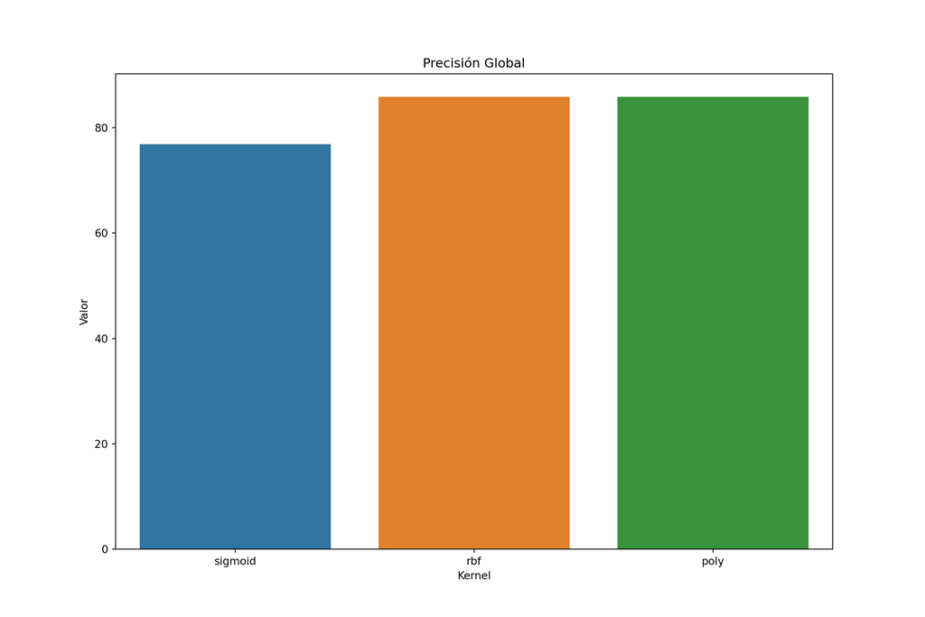

```python
p_global = res.loc[res.Precision == "Global", ]
fig, ax = plt.subplots(figsize = (12, 8))
sns.barplot(x = 'Kernel', y = 'Valor', data = p_global)
plt.title("Precisión Global")
plt.show()
```

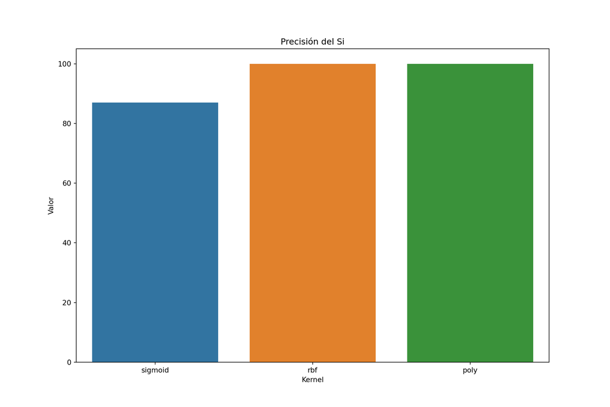

```python
p_si = res.loc[res.Precision == "Si", ]
fig, ax = plt.subplots(figsize = (12, 8))
sns.barplot(x = 'Kernel', y = 'Valor', data = p_si)
plt.title("Precisión del Si")
plt.show()
```

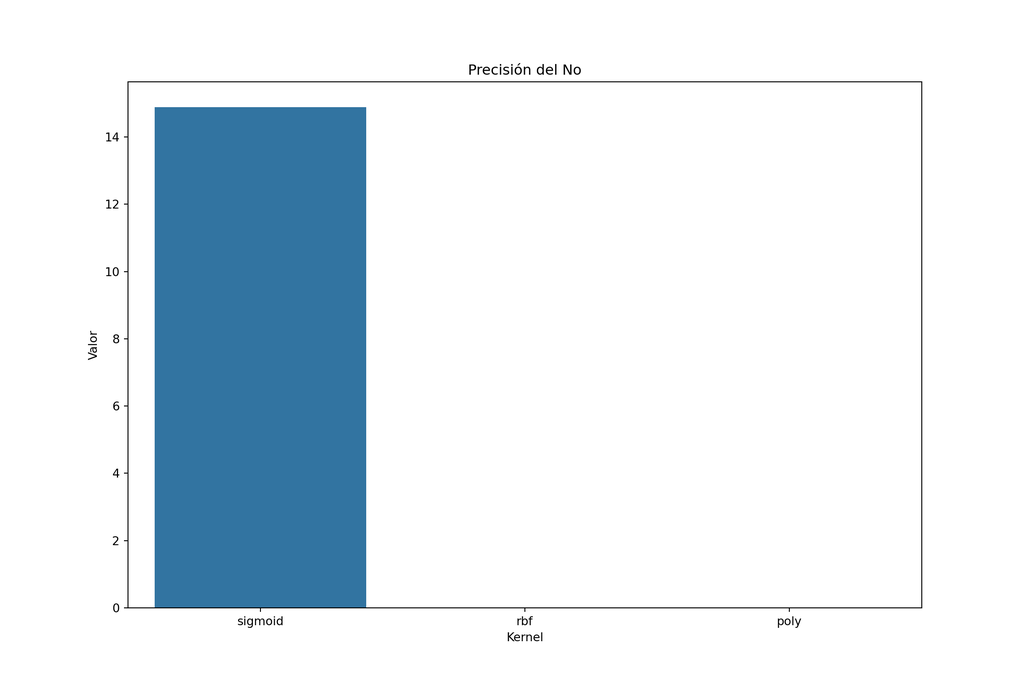

```python
p_no = res.loc[res.Precision == "No", ]
fig, ax = plt.subplots(figsize = (12, 8))
sns.barplot(x = 'Kernel', y = 'Valor', data = p_no)
plt.title("Precisión del No")
plt.show()
```

## Ejemplo 2

### Ejemplo con los datos de Scoring de Crédito.

### Calibración de los modelos predictivos.

### **Se deberían calibrar todos antes, es decir, tal y como hicimos con Máquinas de Soporte Vectorial, deberíamos encontrar la mejor combinación de parámetros en cada método antes de ponerlos a competir. Así se debe hacer en problemas de la vida real, por ahora los vamos a poner a competir a todos con su parametrización que usa por defecto.**

```python
# Se leen los datos
datos = pd.read_csv('datos/MuestraCredito5000V2.csv',delimiter=';',decimal=".")

# Convierte las variables de object a categórica
datos['IngresoNeto'] = datos['IngresoNeto'].astype('category')
datos['CoefCreditoAvaluo'] = datos['CoefCreditoAvaluo'].astype('category')
datos['MontoCuota'] = datos['MontoCuota'].astype('category')
datos['GradoAcademico'] = datos['GradoAcademico'].astype('category')
# Recodifica las categorías usando números
datos["MontoCuota"] = datos["MontoCuota"].cat.codes
datos["GradoAcademico"] = datos["GradoAcademico"].cat.codes
# Convierte las variables de entero a categórica
datos['MontoCuota'] = datos['MontoCuota'].astype('category')
datos['GradoAcademico'] = datos['GradoAcademico'].astype('category')

# Prepara los datos
X = datos.iloc[:,:5]
y = datos.iloc[:,5:6]
```

### 1. Método KNN

```python
from sklearn.neighbors import KNeighborsClassifier

instancia_kfold = KFold(n_splits=10)
prediccion = cross_val_predict(KNeighborsClassifier(n_neighbors=71),
                              X, y.iloc[:,0].values, cv=instancia_kfold)
print("Predicción:\n{}".format(prediccion))
```

```
## Predicción:
## ['Si' 'Si' 'Si' ... 'Si' 'Si' 'Si']
```

```python
mc_knn = confusion_matrix(y, prediccion)
mc_knn
```

```
## array([[   0,  705],
##        [   0, 4295]])
```

### 2. Método Árboles

```python
from sklearn.tree import DecisionTreeClassifier

instancia_kfold = KFold(n_splits=10)
prediccion = cross_val_predict(DecisionTreeClassifier(),
                              X, y.iloc[:,0].values, cv=instancia_kfold)
print("Predicción:\n{}".format(prediccion))
```

```
## Predicción:
## ['Si' 'Si' 'Si' ... 'No' 'No' 'No']
```

```python
mc_arbol = confusion_matrix(y, prediccion)
mc_arbol
```

```
## array([[ 478,  227],
##        [ 252, 4043]])
```

### 3. Bosques Aleatorios

```python
from sklearn.ensemble import RandomForestClassifier

instancia_kfold = KFold(n_splits=10)
prediccion = cross_val_predict(RandomForestClassifier(n_estimators=10),
                              X, y.iloc[:,0].values, cv=instancia_kfold)
print("Predicción:\n{}".format(prediccion))
```

```
## Predicción:
## ['Si' 'Si' 'Si' ... 'No' 'Si' 'No']
```

```python
mc_bosques = confusion_matrix(y, prediccion)
mc_bosques
```

```
## array([[ 489,  216],
##        [ 225, 4070]])
```

### 4. Potenciación (Boosting)

```python
from sklearn.ensemble import AdaBoostClassifier

instancia_kfold = KFold(n_splits=10)
prediccion = cross_val_predict(AdaBoostClassifier(n_estimators=10),
                              X, y.iloc[:,0].values, cv=instancia_kfold)
print("Predicción:\n{}".format(prediccion))
```

```
## Predicción:
## ['Si' 'No' 'Si' ... 'Si' 'Si' 'Si']
```

```python
mc_potenciacion = confusion_matrix(y, prediccion)
mc_potenciacion
```

```
## array([[  60,  645],
##        [  94, 4201]])
```

### 5. Potenciación Extrema (XGBoosting)

```python
from sklearn.ensemble import GradientBoostingClassifier

instancia_kfold = KFold(n_splits=10)
prediccion = cross_val_predict(GradientBoostingClassifier(n_estimators=10),
                              X, y.iloc[:,0].values, cv=instancia_kfold)
print("Predicción:\n{}".format(prediccion))
```

```
## Predicción:
## ['No' 'Si' 'No' ... 'Si' 'Si' 'Si']
```

```python
mc_xg_potenciacion = confusion_matrix(y, prediccion)
mc_xg_potenciacion
```

```
## array([[ 207,  498],
##        [  49, 4246]])
```

### 6. Máquinas de Soporte Vectorial

```python
from sklearn.svm import SVC

instancia_kfold = KFold(n_splits=10)
prediccion = cross_val_predict(SVC(kernel='rbf', gamma = 'scale'),
                              X, y.iloc[:,0].values, cv=instancia_kfold)
print("Predicción:\n{}".format(prediccion))
```

```
## Predicción:
## ['Si' 'Si' 'Si' ... 'Si' 'Si' 'Si']
```

```python
mc_svm = confusion_matrix(y, prediccion)
mc_svm
```

```
## array([[   0,  705],
##        [   0, 4295]])
```

### 7. Método Ingenuo de Bayes

```python
from sklearn.naive_bayes import GaussianNB

instancia_kfold = KFold(n_splits=10)
prediccion = cross_val_predict(GaussianNB(), X, y.iloc[:,0].values, cv=instancia_kfold)
print("Predicción:\n{}".format(prediccion))
```

```
## Predicción:
## ['Si' 'Si' 'Si' ... 'Si' 'Si' 'Si']
```

```python
mc_bayes = confusion_matrix(y, prediccion)
mc_bayes
```

```
## array([[  58,  647],
##        [ 189, 4106]])
```

### 8. Análisis Discriminte Lineal

```python
from sklearn.discriminant_analysis import LinearDiscriminantAnalysis

instancia_kfold = KFold(n_splits=10)
prediccion = cross_val_predict(LinearDiscriminantAnalysis(solver = 'lsqr', shrinkage = 'auto'),
                               X, y.iloc[:,0].values, cv=instancia_kfold)
print("Predicción:\n{}".format(prediccion))
```

```
## Predicción:
## ['Si' 'No' 'Si' ... 'Si' 'Si' 'Si']
```

```python
mc_dis_lineal = confusion_matrix(y, prediccion)
mc_dis_lineal
```

```
## array([[  12,  693],
##        [ 135, 4160]])
```

### 9. Análisis Discriminte Cuadrático

```python
from sklearn.discriminant_analysis import QuadraticDiscriminantAnalysis

instancia_kfold = KFold(n_splits=10)
prediccion = cross_val_predict(QuadraticDiscriminantAnalysis(),
                              X, y.iloc[:,0].values, cv=instancia_kfold)
print("Predicción:\n{}".format(prediccion))
```

```
## Predicción:
## ['No' 'No' 'No' ... 'Si' 'Si' 'Si']
```

```python
mc_dis_cuadratico = confusion_matrix(y, prediccion)
mc_dis_cuadratico
```

```
## array([[  86,  619],
##        [ 238, 4057]])
```

### Gráfico Comparativo

```python
import numpy as np
import seaborn as sns
import matplotlib.pyplot as plt

labels = ['KNN', 'Arbol', 'Bosques', 'Potenciacion', 'XGB', 'SVM', 'Bayes', 'Lineal', 'Cuadratico']

mcs = [mc_knn, mc_arbol, mc_bosques, mc_potenciacion, mc_xg_potenciacion,
       mc_svm, mc_bayes, mc_dis_lineal, mc_dis_cuadratico]

res = pd.DataFrame()
for i in range(9):
  PG = np.round(np.diag(mcs[i]).sum() / mcs[i].sum() * 100, 2)
  PC = np.round(mcs[i].diagonal()/np.sum(mcs[i],axis = 1) * 100, 2)
  PP = PC[1]
  PN = PC[0]

  res = pd.concat([res, pd.DataFrame([[labels[i], "Global", PG]], columns = ["Modelo", "Precision", "Valor"])])
  res = pd.concat([res, pd.DataFrame([[labels[i], "Si", PP]], columns = ["Modelo", "Precision", "Valor"])])
  res = pd.concat([res, pd.DataFrame([[labels[i], "No", PN]], columns = ["Modelo", "Precision", "Valor"])])
```

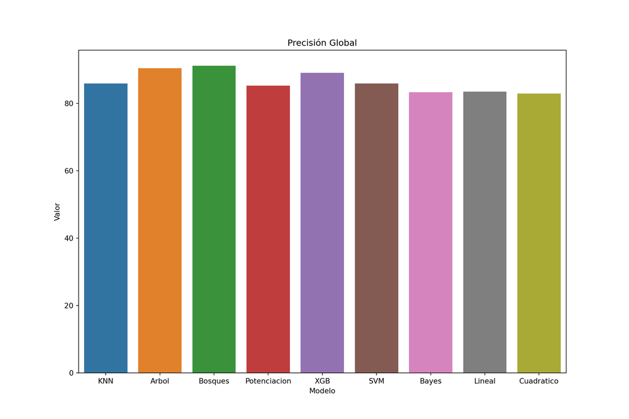

```python
p_global = res.loc[res.Precision == "Global", ]
fig, ax = plt.subplots(figsize = (12, 8))
sns.barplot(x = 'Modelo', y = 'Valor', data = p_global)
plt.title("Precisión Global")
plt.show()
```

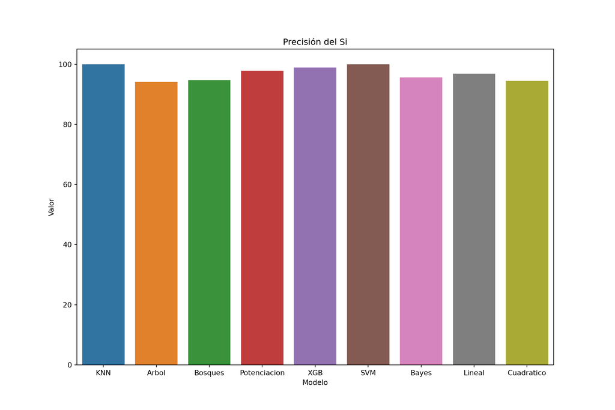

```python
p_si = res.loc[res.Precision == "Si", ]
fig, ax = plt.subplots(figsize = (12, 8))
sns.barplot(x = 'Modelo', y = 'Valor', data = p_si)
plt.title("Precisión del Si")
plt.show()
```

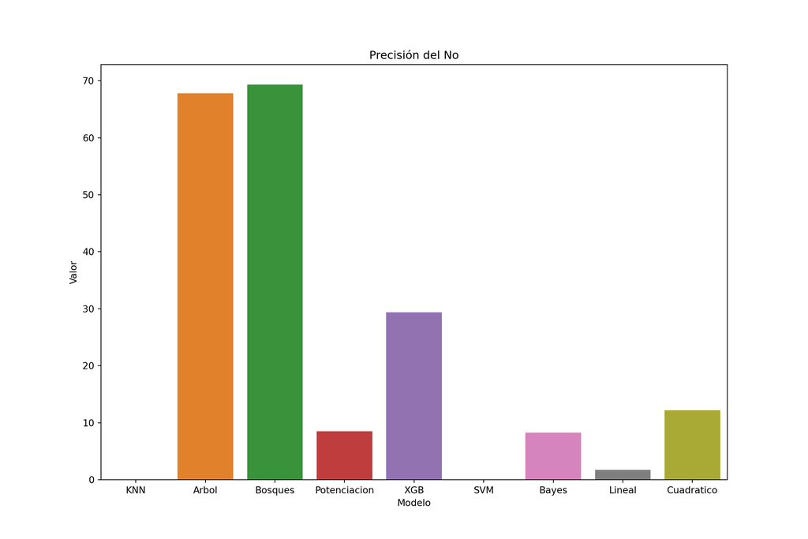

```python
p_no = res.loc[res.Precision == "No", ]
fig, ax = plt.subplots(figsize = (12, 8))
sns.barplot(x = 'Modelo', y = 'Valor', data = p_no)
plt.title("Precisión del No")
plt.show()
```